# Genomic Variants: Introduction to exomeSeq data

Jineta Banerjee

03 September, 2020

# 1 Getting Started

The scope of this document is to inform participants:

- how to navigate the Synapse environment to access and work with the data files
- display the key features of the genomic variant (exomeSeq) dataset
- introduce few general analyses steps of the data and their interpretation

At the end of this document, the participants will be able to download the data and understand various intricacies that exist in this given dataset. We encourage participants to visualize the dataset by faceting on different variables to get an accurate understanding of the dataset.

## 1.1 Loading Analytical Packages

Lets first load the R packages we need to query, download, and analyze the data that is stored on Synapse.

```r
library(synapser)
library(synapserutils)
library(BiocManager)
library(gProfileR)
library(tidyverse)
library(DT)
library(maftools)
library(here)
library(ggfortify)
library(stringr)
library(reshape2)
library(sagethemes)


## The login credentials have been stored in .synapseConfig file in the home dir. If you dont have this setup, please make the file before trying to login.
synLogin()
```

```
## Welcome, Jineta Banerjee!
```

```r
#Make a diverse color spectrum
#vc_cols = RColorBrewer::brewer.pal(n = 100, name = 'Spectral')
vc_cols = sage_colors %>%
  unlist()
vc_cols = vc_cols[seq(2, length(vc_cols), 5)]
```

## 1.2 Accessing or downloading data from Synapse

Please look up the SynID of the relevant data table and access it using the **synTableQuery** command of *synapser*. This file contains genomic variant data that has been collected from NF1 patients by various researchers as a part of various different studies.

```r
entity <- synGet("syn20812188")  # download file
exome_data <- synTableQuery("SELECT * FROM syn20812188")$asDataFrame()
```

# 2 Exploring the data files

## 2.1 Structure of the file

Lets first take a brief look at the contents of the accessed file:

```r
# Clean up dataframe

exome_data$sex[exome_data$sex == "male"] <- "Male"
exome_data$sex[exome_data$sex == "female"] <- "Female"
exome_data <- exome_data[,-c(1:2)]

##Inspect the file
print("Contents of the file:")
```

```
## [1] "Contents of the file:"
```

```r
head(exome_data)
```

|  | Tumor_Sample_Barcode | Hugo_Symbol | Entrez_Gene_Id | Center | NCBI_Build | Chromosome | Start_Position | End_Position | Strand | Variant_Classification | Variant_Type | Reference_Allele | Tumor_Seq_Allele1 | Tumor_Seq_Allele2 | dbSNP_RS | dbSNP_Val_Status | Matched_Norm_Sample_Barcode | Match_Norm_Seq_Allele1 | Match_Norm_Seq_Allele2 | Tumor_Validation_Allele1 | Tumor_Validation_Allele2 | Match_Norm_Validation_Allele1 | Match_Norm_Validation_Allele2 | Verification_Status | Validation_Status | Mutation_Status | Sequencing_Phase | Sequence_Source | Validation_Method | … |
| --- | --- | --- | --- | --- | --- | --- | --- | --- | --- | --- | --- | --- | --- | --- | --- | --- | --- | --- | --- | --- | --- | --- | --- | --- | --- | --- | --- | --- | --- | --- |
| 1 | 136816-1163242085 | SAMD11 | 148398 | . | GRCh37 | 1 | 877831 | 877831 | + | Missense_Mutation | SNP | T | C | C | rs6672356 | NA | NORMAL | T | T | NA | NA | NA | NA | NA | NA | NA | NA | NA | NA | … |
| 2 | 136816-1163242085 | NOC2L | 26155 | . | GRCh37 | 1 | 888659 | 888659 | + | Missense_Mutation | SNP | T | T | C | rs3748597 | NA | NORMAL | T | T | NA | NA | NA | NA | NA | NA | NA | NA | NA | NA | … |
| 3 | 136816-1163242085 | NOC2L | 26155 | . | GRCh37 | 1 | 889238 | 889238 | + | Missense_Mutation | SNP | G | G | A | rs3828049 | NA | NORMAL | G | G | NA | NA | NA | NA | NA | NA | NA | NA | NA | NA | … |
| 4 | 136816-1163242085 | NOC2L | 26155 | . | GRCh37 | 1 | 892488 | 892488 | + | Frame_Shift_Del | DEL | A | A | - | rs778382476 | NA | NORMAL | A | A | NA | NA | NA | NA | NA | NA | NA | NA | NA | NA | … |
| 5 | 136816-1163242085 | PLEKHN1 | 84069 | . | GRCh37 | 1 | 909238 | 909238 | + | Missense_Mutation | SNP | G | C | C | rs3829740 | NA | NORMAL | G | G | NA | NA | NA | NA | NA | NA | NA | NA | NA | NA | … |
| 6 | 136816-1163242085 | PLEKHN1 | 84069 | . | GRCh37 | 1 | 909309 | 909309 | + | Missense_Mutation | SNP | T | T | C | rs3829738 | NA | NORMAL | T | T | NA | NA | NA | NA | NA | NA | NA | NA | NA | NA | … |

The following table contains descriptions of some of the metadata variables included in the data file:

[output not shown]

For more information regarding the various columns in the dataset please visit here: https://docs.gdc.cancer.gov/Data/File_Formats/MAF_Format/#vep

## 2.2 Metadata

The metadata in a healthcare study includes descriptions of the specimens, and the details of the studies they originated from. We can explore the metadata by visualizing various aspects of it to get a sense of the data contained within our dataset and put it in context of the disease and patients.

For example, we can visualize the data distribution according to sex.

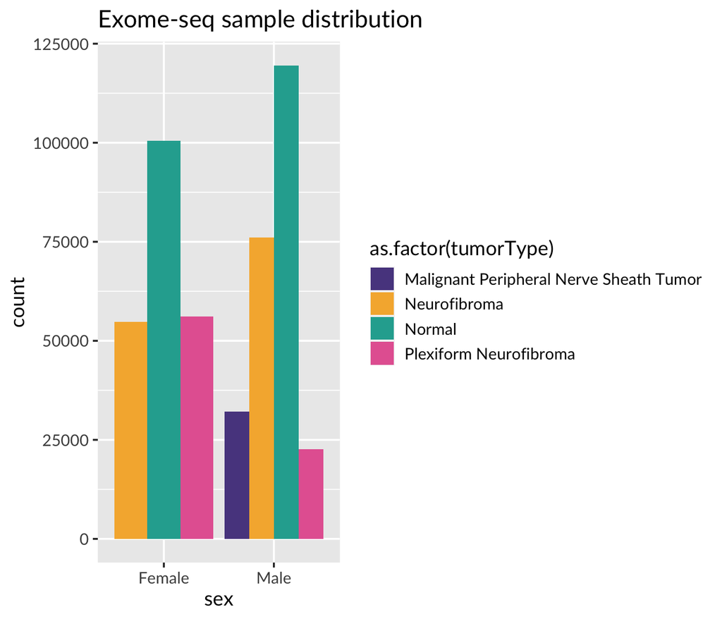

```r
#Plot Metadata
exome_data %>% group_by(Tumor_Sample_Barcode) %>%
ggplot(aes(x=sex))+
    geom_bar(aes(x=sex,fill=as.factor(tumorType)),position='dodge')+
    #scale_fill_brewer(palette="Spectral")+
    ggtitle('Exome-seq sample distribution')+
  scale_fill_sage_d() +
  theme_sage()
```

We can also look at the different types of mutations observed for various genes in our dataset according to the tumor type. The different types of variants recognized in our dataset include:

| Variant_classification | Description |
| --- | --- |
| Nonsense_Mutation | Mutation leading to change of a coding codon to stop codon |
| Splice_Site | Mutation leading to change in splice site |
| Missense_Mutation | Mutation resulting in change in amino acid |
| In_Frame_Del | Deletion of nucleotides divisible by three leading to deletions of amino acids |
| In_Frame_Ins | Insertion of nucleotides divisible by three leading to insertion of amino acids |
| Frame_Shift_Ins | Insertions of nucleotides (not divisible by three) such that codons downstream of the insertion are shifted resulting in a malformed protein or nonsense-mediated decay |
| Frame_Shift_Del | Deletions of nucleotides (not divisible by three) such that codons downstream of the deletion are shifted resulting in a malformed protein or nonsense-mediated decay |
| Translation_Start_Site | Mutation causing changes in translation start site |
| Nonstop_Mutation | SNP in stop codon that disrupts the stop codon causing continued translation |

More information regarding variants can be found [here](https://uswest.ensembl.org/info/genome/variation/prediction/classification.html#classes)

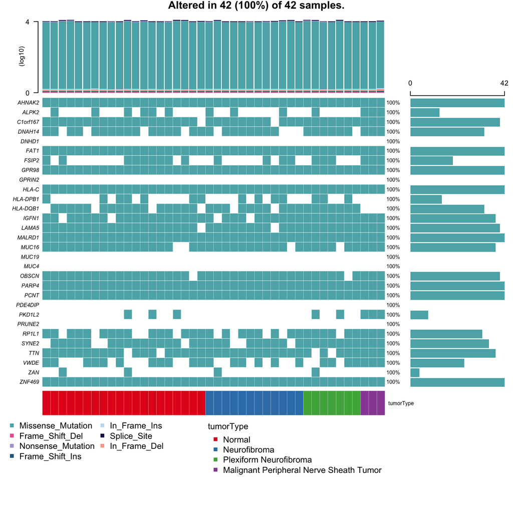

```r
#Parse out anno and data from csv
anno <- exome_data[, c("Tumor_Sample_Barcode", "id", "age", "assay", "diagnosis",
                     "individualID", "nf1Genotype","nf2Genotype","organ","isCellLine", "sex",
                     "species", "specimenID", "study", "studyId", "disease","tumorType")]
anno <- unique(anno)

drop_cols <- c("id", "age", "assay", "diagnosis",
                     "individualID", "nf1Genotype","nf2Genotype","organ","isCellLine", "sex",
                     "species", "specimenID", "study", "studyId", "disease","tumorType")
maf <- exome_data[, !(names(exome_data) %in% drop_cols)]

mut_vec <- c(
  "Nonsense_Mutation",
  "Splice_Site",
  "Missense_Mutation",
  "In_Frame_Del",
  "In_Frame_Ins",
  "Frame_Shift_Ins",
  "Frame_Shift_Del",
  "Translation_Start_Site",
  "Nonstop_Mutation",
  "IGR"
)
# Use read.maf to make maf object
maf_exome <- read.maf(maf = maf, clinicalData = anno, vc_nonSyn = mut_vec, verbose = FALSE) #use maftools to generate visualizations

#Make color spectrum
names(vc_cols) = mut_vec


#Oncoplot / Waterfall plot
oncoplot(maf = maf_exome, top = 30,
         colors = vc_cols, fontSize = 0.5, fill = FALSE,
         logColBar = TRUE, clinicalFeatures = "tumorType", sortByAnnotation = TRUE,
         removeNonMutated = FALSE, bgCol = "#FFFFFF")
```

We can zoom in on a few of our favorite genes to explore the different flavors of mutations that genes may carry.

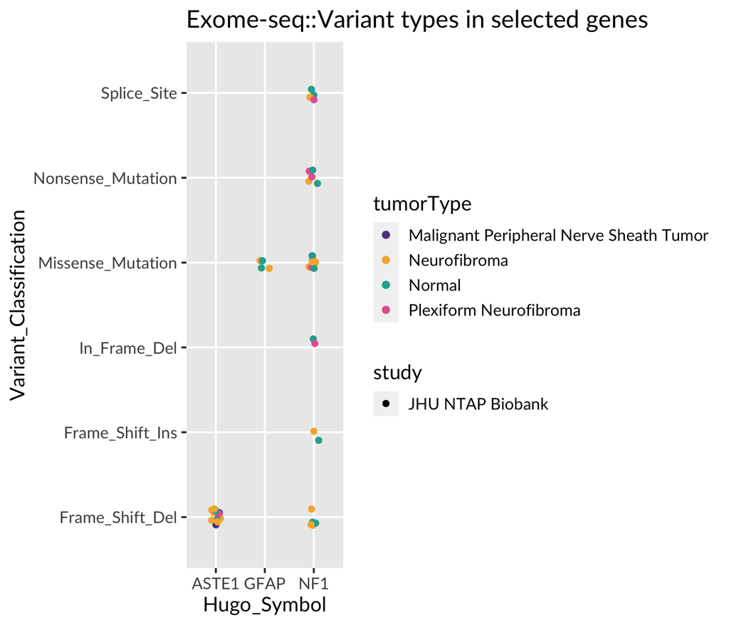

```r
#Plot genes with metadata
analyzeMetdataWithGenes<-function(datafile,prefix, gene_a, ...){
  #look at some marker genes using normalized zScore
  ggplot(subset(datafile,Hugo_Symbol%in%c(gene_a, ...)))+
    geom_jitter(aes(x=Hugo_Symbol,
                    y=Variant_Classification,
                    shape=study,col=tumorType),
                width =0.1, size=2, height = 0.1)+
    ggtitle(paste(prefix,'Variant types in selected genes', sep = '::'))+
    scale_color_sage_d() +
    theme_sage()
}
analyzeMetdataWithGenes(exome_data, "Exome-seq", "NF1", "GFAP", "ASTE1")
```

# 3 Data Analysis

## 3.1 Dimensionality Reduction

To explore the data and find meaningful differences between samples, we first perform a simplistic principal component analysis, and explore the genes that are top contributors to the first few principal components.

We tested the hypothesis whether the number of mutations in a set of genes can be used for clustering the data/samples into meaningful groups. For this, we first created a scoring matrix by converting variant data into numerical variables for PCA.

```r
# Filter select columns for analysis
select_df <- exome_data[, c("Hugo_Symbol", "Entrez_Gene_Id", "Chromosome", "Start_Position", "Variant_Type",
                            "Transcript_ID", "HGVSp_Short", "BIOTYPE", "SWISSPROT", "RefSeq", "PolyPhen",
                            "IMPACT", "FILTER", "id", "assay", "diagnosis", "individualID", "isCellLine",
                            "organ", "sex", "species", "study", "tumorType", "gnomAD_AF", "gnomAD_AFR_AF",
                            "gnomAD_AMR_AF", "gnomAD_ASJ_AF", "gnomAD_EAS_AF", "gnomAD_FIN_AF", "gnomAD_NFE_AF",
                            "gnomAD_OTH_AF", "gnomAD_SAS_AF")]

# Make dummy variables for PCA
select_df <- select_df %>% mutate(isSNP = as.numeric(select_df$Variant_Type == "SNP"))
select_df <- select_df %>% mutate(isDEL = as.numeric(select_df$Variant_Type == "DEL"))
select_df <- select_df %>% mutate(isDNP = as.numeric(select_df$Variant_Type == "DNP"))
select_df <- select_df %>% mutate(isINS = as.numeric(select_df$Variant_Type == "INS"))
select_df <- select_df %>% mutate(isONP = as.numeric(select_df$Variant_Type == "ONP"))
select_df <- select_df %>% mutate(isTNP = as.numeric(select_df$Variant_Type == "TNP"))
select_df <- select_df %>% mutate(totHits = rowSums(select_df[,c(33:38)]))

# Filter out well known common variants to look for rare mutations, and select mutations with annotated "HIGH" impact on proteins
impact_df <- select_df[(select_df$IMPACT == "HIGH" & select_df$FILTER != "common_variant"),]
```

We used the number of mutational events (*hits*) to the genes as a scoring metric for each gene to do our principal component analysis. Since some genomic variants can be quite common and many of them are well tolerated, we filtered out all known common_variants in the genes and selected for the ones with high impact on proteins to strengthen the signal for PCA.

```r
doPcaHitPlots<-function(datafile, env){
  #create matrix
  combined.mat=reshape2::acast(datafile,
                               Hugo_Symbol~id,
                               value.var="totHits",
                               fun.aggregate = sum)

  ###PCA
  env$tab <- autoplot(prcomp(t(combined.mat)))

  ###Look at genes contributing to PCs
  loads=prcomp(combined.mat)$x

  genes1=rownames(combined.mat)[rev(order(loads[,1]))[1:25]]

  #now take those loadings from pc1
  env$tab1 <- ggplot(subset(datafile,Hugo_Symbol%in%genes1[1:5]))+
                    geom_jitter(aes(x=Hugo_Symbol,
                                    y=Variant_Type,
                                    col=tumorType,
                                    shape=study),
                                width = 0.1, size = 1)+
                    ggtitle('Selected genes from PC1')+
    scale_color_sage_d() +
    theme_sage()

  genes2=rownames(combined.mat)[rev(order(loads[,2]))[1:25]]

  #now take those loadings from pc2
  env$tab2 <- ggplot(subset(datafile,Hugo_Symbol%in%genes2[1:5]))+
              geom_jitter(aes(x=Hugo_Symbol,
                              y=Variant_Type,
                              col=tumorType,
                              shape=study),
                          width = 0.1, size = 1)+
              ggtitle('Selected genes from PC2')+
    scale_color_sage_d() +
    theme_sage()
}


myEnv <- new.env()
doPcaHitPlots(impact_df, myEnv)
print("PCA: excluding common variants (scoring metric : no. of hits)")
```

```
## [1] "PCA: excluding common variants (scoring metric : no. of hits)"
```

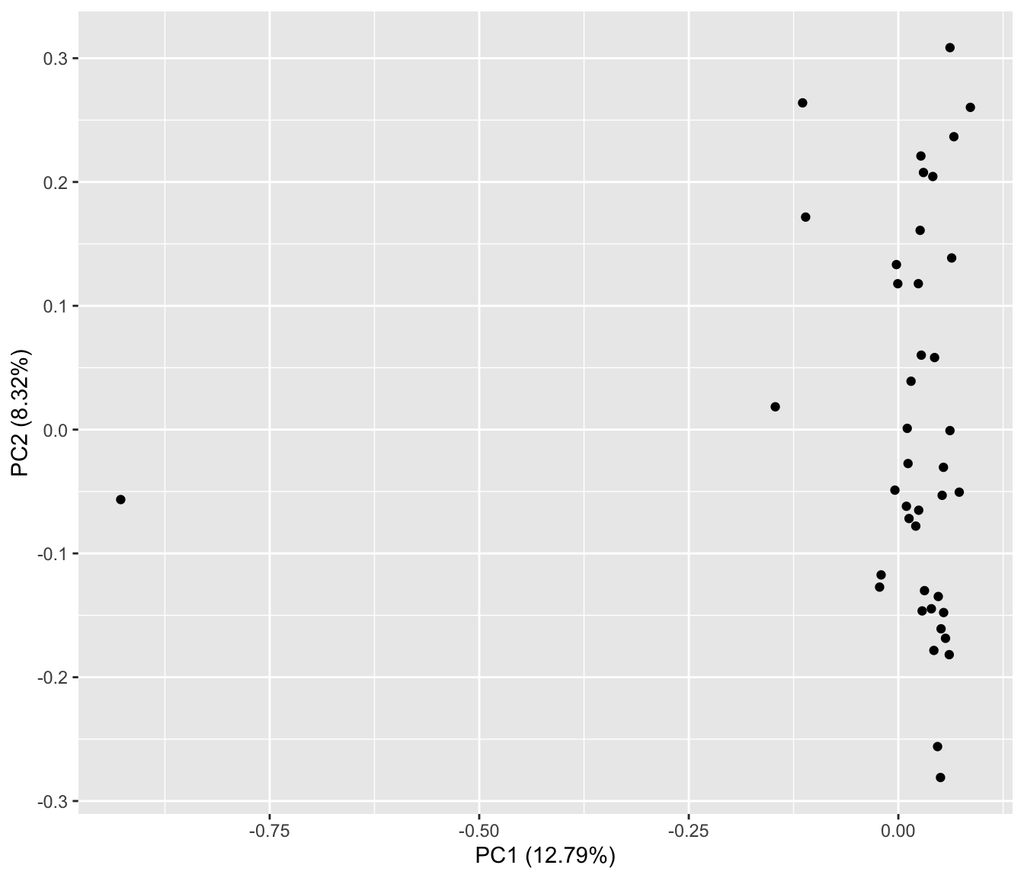

```r
myEnv$tab
```

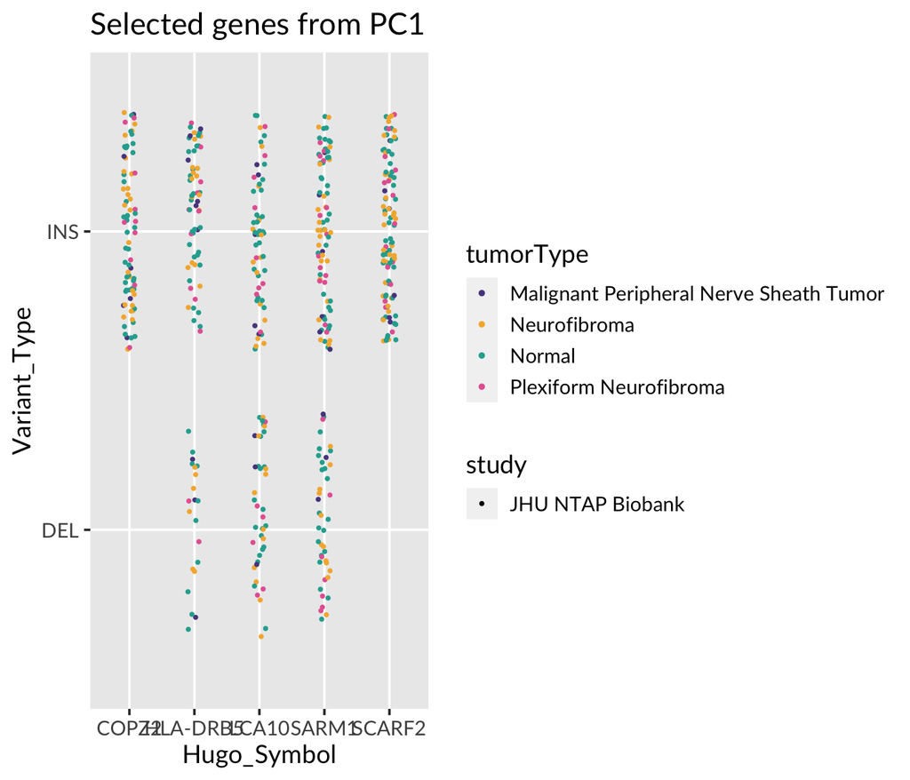

```r
myEnv$tab1
```

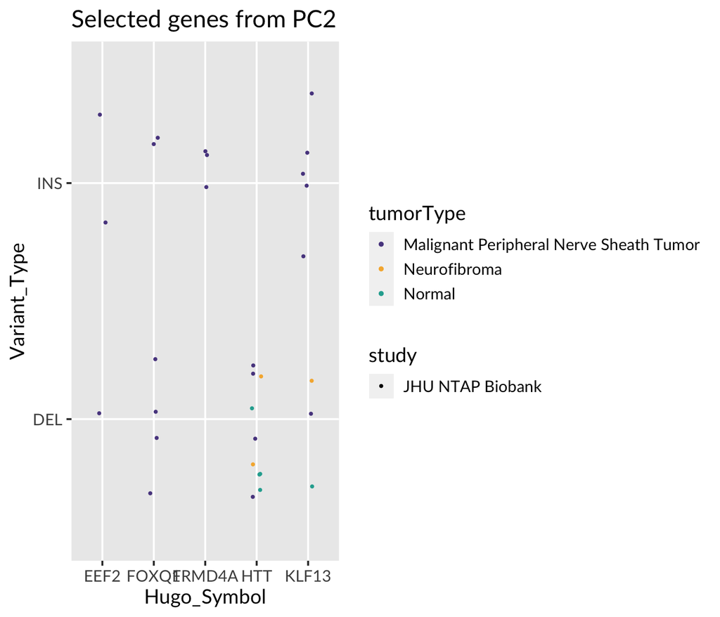

```r
myEnv$tab2
```

However, even with our best efforts to select relevant mutations, the first principal component explains only 13% of the variance in the data. We encourage the participants to explore other variables present in the dataset and combinations thereof to find more significant sources of variance within the data.